# HW01

## 1. Problem 1

#### (b)

Since $Z=\frac{1}{(X-2)^2}$, then we can get the $F_Z(x)=\textrm{P}[Z\leq x]$, therefore
$$F_z(x)=\mathrm{P}[\frac{1}{(X-2)^2}\leq x]=P[(X-2)\geq\frac{1}{\sqrt x}\cup(X-2)\leq -\frac{1}{\sqrt x}]$$
if $x\leq 0$, then $F_z(x)=0$, otherwise
$$F_Z(x)=F_x(2-\frac{1}{\sqrt x}) + (1-F_x(2+\frac{1}{\sqrt x}))$$
When $x\leq\frac{1}{4}\rightarrow 2-\frac{1}{\sqrt x}\leq 0$, we have
$$F_z(x)=\frac{1}{2}e^{-\frac{\sqrt 2}{2}(2-\frac{1}{\sqrt x})}+\frac{1}{2}e^{-\frac{\sqrt 2}{2}(2+\frac{1}{\sqrt x})}$$
Since $F_z(\frac{1}{4})\geq\frac{1}{2}>0.1$,we just need to consider $F_z(x)=0.1$, so we get
$$x_{0.1}\approx0.05267$$

## 2. Problem 2

#### (a)

Since $r\sim N(0, 0.025)$ and $r=\ln(R+1)$, we have $\frac{\ln(R+1)}{0.025}\sim N(0, 1)$, therefore
$$R_{total}=1e8\cdot R_{0.002}=1e8\cdot(e^{0.025\Phi(0.002)}-1)\approx-6942634$$

#### (b)

- When $\nu=0.5$, the quantile can be computed by the following R command

```r
library(fGarch)
res <- (exp(qged(0.025, 0, 0.025, 0.5))-1)*100000000
```

So the result is $-5006212$

- When $\nu=0.9$, the quantile can be computed in the same way and the result is $-5189489$
- When $\nu=1.4$, the quantile can be computed in the same way and the result is $-4995869$

## 3. Problem 3

#### (a)

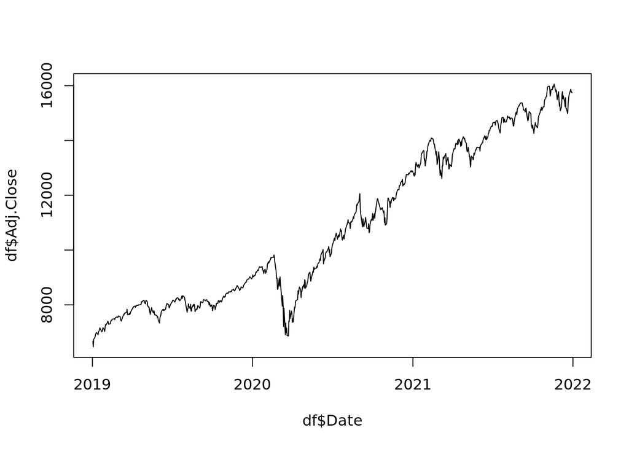

```r
df <- read.csv("../Nasdaq.csv", header=TRUE)
df$Date <- as.Date(df$Date)
logReturn <- diff(log(df$Adj.Close))
plot(df$Date, df$Adj.Close, type="l")
```

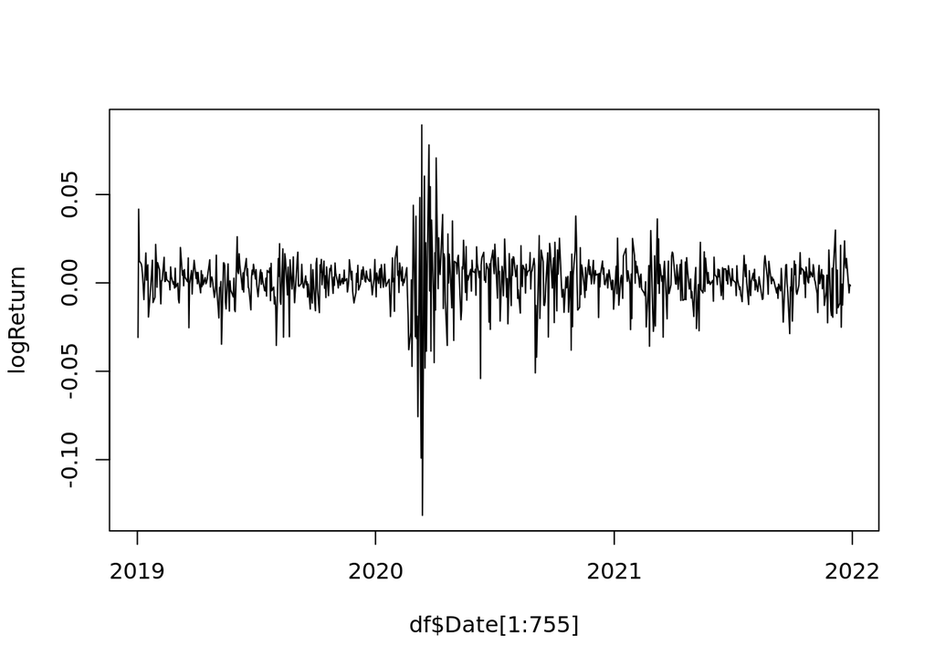

```r
plot(df$Date[1:755], logReturn, type="l")
```

The plot shows that there is a rising trend in the adjusted close, and the mean of the log return is close to 0. The log return is typically in the interval of [-0.05, 0.05], but it will have some extreme value when there is high volatility of the adjusted close price.

#### (b)

```r
skewness(logReturn)
```

```
## [1] -1.047011
## attr(,"method")
## [1] "moment"
```

```r
kurtosis(logReturn)
```

```
## [1] 12.38328
## attr(,"method")
## [1] "excess"
```

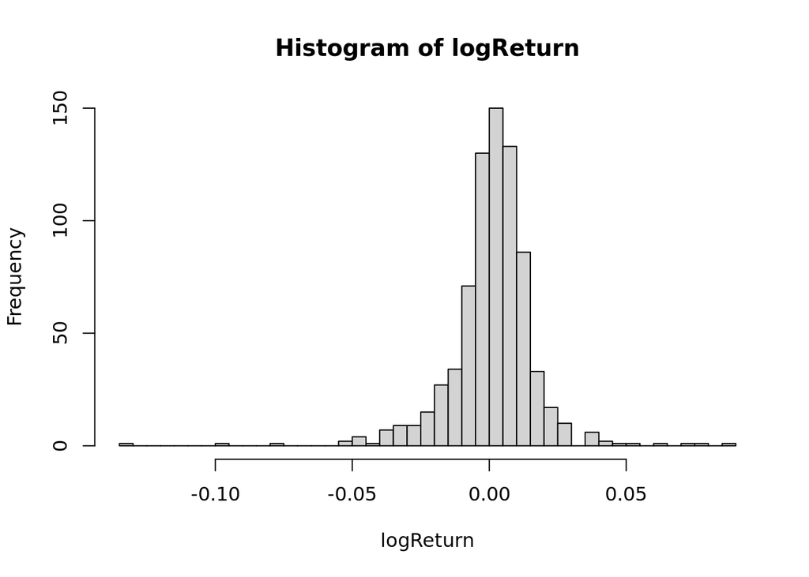

```r
hist(logReturn, breaks=50)
```

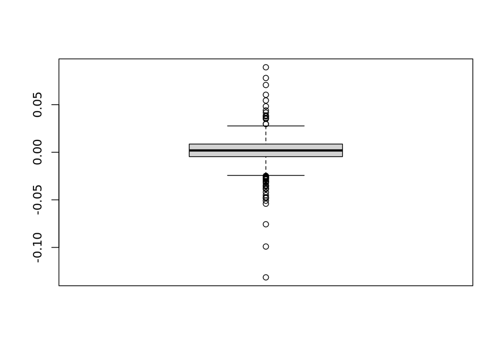

```r
boxplot(logReturn)
```

#### (c)

```r
source('startup.R')
mu <- mean(logReturn)
sigma <- sd(logReturn)
estimated_q <- qdexp(0.004, mu, 2^0.5 / sigma)
q <- quantile(logReturn, 0.004)
```

The estimated mean is 1.138E-3 , and the estimated standard deviation is 1.566E-2

The estimated_quantile is -0.052 and the sample quantile is -0.054. Therefore, the quantile is a bit smaller than the estimated one, but they’re very close.

## 4. Problem 4

#### (a)

The 20-period log return $r_t(20)=\ln\frac{100}{97}=\sum_{i=1}^{20}r_{t+i}$

Since $r_{t+i}$ are i.i.d variables following $N\sim(0.0002, 0.03^2), r_t(20)$ should follow $N\sim(0.004,0.018)$

Then we can compute the probability with R

```r
prob <- 1 - pnorm(log(100/97), 0.004, 0.018^0.5)
```

Therefore, we get the probability equals to 0.4218

#### (b)

We can use binary search to solve this problem

```r
l <- 1
r <- 10000
while(l < r){
    m = floor((l + r) / 2)
    prob <- 1 - pnorm(log(2), 0.0005 * m, 0.012 * m ^ 0.5)
    if(prob < 0.9){
        l <- m + 1
    }
    else{
        r <- m
    }
}
```

Then we get $l$=3099, which means we need 3099 days.